# Exploratory Analysis of World Happiness and Corruption

MUTONI Diane

2026-11-19

# Downloading data and load them to R studio

```r
library(tidyverse)
library(dplyr)
Happiness_corruption<-read.csv("C:/Users/FALCON TECHNOLOGY/Desktop/20252MBI033_R_for_datascience_exam/WorldHappiness_Corruption_2015_2020.csv")
```

#to display the variable names

```r
names(Happiness_corruption)
```

```
##  [1] "Country"           "happiness_score"   "gdp_per_capita"
##  [4] "family"            "health"            "freedom"
##  [7] "generosity"        "government_trust"  "dystopia_residual"
## [10] "continent"         "Year"              "social_support"
## [13] "cpi_score"
```

#the top 5 rows

```r
head(Happiness_corruption,5)
```

```
##       Country happiness_score gdp_per_capita   family    health   freedom
## 1      Norway           7.537       1.616463 1.533524 0.7966665 0.6354226
## 2     Denmark           7.522       1.482383 1.551122 0.7925655 0.6260067
## 3     Iceland           7.504       1.480633 1.610574 0.8335521 0.6271626
## 4 Switzerland           7.494       1.564980 1.516912 0.8581313 0.6200706
## 5     Finland           7.469       1.443572 1.540247 0.8091577 0.6179509
##   generosity government_trust dystopia_residual continent Year social_support
## 1  0.3620122        0.3159638          2.277027    Europe 2015              0
## 2  0.3552805        0.4007701          2.313707    Europe 2015              0
## 3  0.4755402        0.1535266          2.322715    Europe 2015              0
## 4  0.2905493        0.3670073          2.276716    Europe 2015              0
## 5  0.2454828        0.3826115          2.430182    Europe 2015              0
##   cpi_score
## 1        88
## 2        91
## 3        79
## 4        86
## 5        90
```

#the bottom 10rows,

```r
tail(Happiness_corruption,10)
```

```
##         Country happiness_score gdp_per_capita family    health   freedom
## 783      Zambia          3.7594      0.5368338      0 0.3635933 0.4913175
## 784       Haiti          3.7208      0.2847344      0 0.3743667 0.1692975
## 785       India          3.5733      0.7305762      0 0.5405701 0.5811422
## 786      Malawi          3.5380      0.1765347      0 0.4461633 0.4873898
## 787       Yemen          3.5274      0.3927018      0 0.4150002 0.2437215
## 788    Botswana          3.4789      0.9975490      0 0.4941017 0.5090894
## 789    Tanzania          3.4762      0.4571631      0 0.4426779 0.5093431
## 790      Rwanda          3.3123      0.3432427      0 0.5723833 0.6040879
## 791    Zimbabwe          3.2992      0.4255640      0 0.3750376 0.3774047
## 792 Afghanistan          2.5669      0.3007058      0 0.2660515 0.0000000
##     generosity government_trust dystopia_residual     continent Year
## 783 0.25062090      0.086705238         1.1343393        Africa 2020
## 784 0.46390966      0.161935672         1.6199169 South America 2020
## 785 0.23707248      0.105587982         0.7341309          Asia 2020
```

[output cut: 18 more lines]

#the data type of each variable

```r
str(Happiness_corruption)
```

```
## 'data.frame':    792 obs. of  13 variables:
##  $ Country          : chr  "Norway" "Denmark" "Iceland" "Switzerland" ...
##  $ happiness_score  : num  7.54 7.52 7.5 7.49 7.47 ...
##  $ gdp_per_capita   : num  1.62 1.48 1.48 1.56 1.44 ...
##  $ family           : num  1.53 1.55 1.61 1.52 1.54 ...
##  $ health           : num  0.797 0.793 0.834 0.858 0.809 ...
##  $ freedom          : num  0.635 0.626 0.627 0.62 0.618 ...
##  $ generosity       : num  0.362 0.355 0.476 0.291 0.245 ...
##  $ government_trust : num  0.316 0.401 0.154 0.367 0.383 ...
##  $ dystopia_residual: num  2.28 2.31 2.32 2.28 2.43 ...
##  $ continent        : chr  "Europe" "Europe" "Europe" "Europe" ...
##  $ Year             : int  2015 2015 2015 2015 2015 2015 2015 2015 2015 2015 ...
##  $ social_support   : num  0 0 0 0 0 0 0 0 0 0 ...
##  $ cpi_score        : int  88 91 79 86 90 84 83 91 89 79 ...
```

#the shape of the dataset

```r
dim(Happiness_corruption)
```

```
## [1] 792  13
```

# check for duplicate rows

```r
sum(duplicated(Happiness_corruption))
```

```
## [1] 0
```

the result for the codes above shows that there are no duplicate rows in our dataset

#find the number of missing values in each column

```r
colSums(is.na(Happiness_corruption))
```

```
##           Country   happiness_score    gdp_per_capita            family
##                 0                 0                 0                 0
##            health           freedom        generosity  government_trust
##                 0                 0                 0                 0
## dystopia_residual         continent              Year    social_support
##                 0                 0                 0                 0
##         cpi_score
##                 0
```

In the above commands,the output shows us that there are no missing values in our dataset

#use of box plot to check if there are any outliers in the quantitative variables.

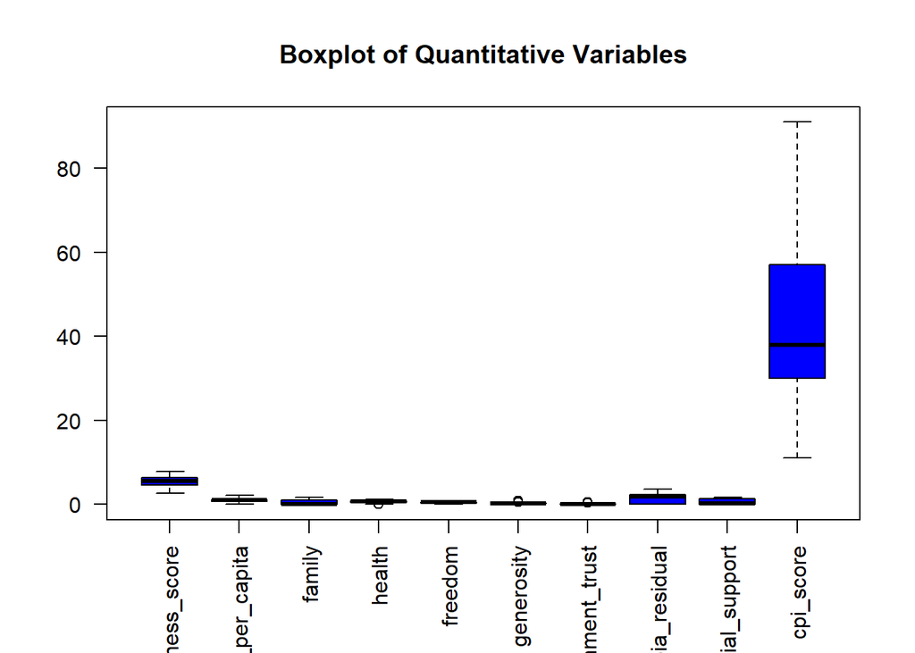

```r
# Select numeric variables
numeric_data <- Happiness_corruption[sapply(Happiness_corruption, is.numeric)]


numeric_data$Year <- NULL

# Create boxplots
boxplot(numeric_data,
        main = "Boxplot of Quantitative Variables",
        col = "blue",
        las = 2)
```

#detecting outliers

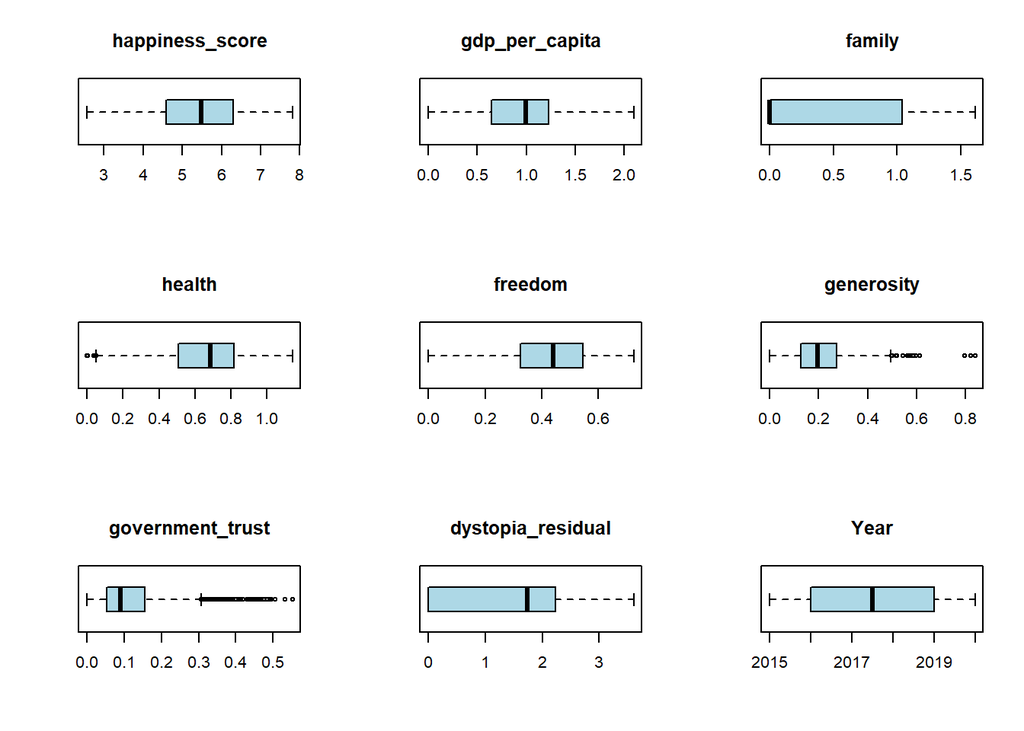

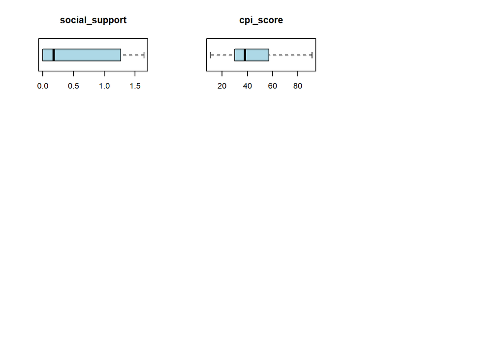

```r
numeric_data <- Happiness_corruption %>%
  select(where(is.numeric))

par(mfrow = c(3, 3))

for (col in names(numeric_data)) {
  boxplot(
    numeric_data[[col]],
    main = col,
    col = "lightblue",
    horizontal = TRUE
  )
}
```

## 4.2 Descriptive summaries and graphs

#Summarize the dataset by Continent

```r
continent_summary <- Happiness_corruption %>%
  group_by(continent) %>%
  summarise(Observations = n(),
            Mean_Happiness = mean(happiness_score, na.rm = TRUE),
            Mean_CPI = mean(cpi_score, na.rm = TRUE),
            Mean_GDP = mean(gdp_per_capita, na.rm = TRUE),
            .groups = "drop") %>%
  arrange(desc(Observations))

print(continent_summary, digits = 3,
      caption = "Summary statistics by continent")
```

```
## # A tibble: 6 × 5
##   continent     Observations Mean_Happiness Mean_CPI Mean_GDP
##   <chr>                <int>          <dbl>    <dbl>    <dbl>
## 1 Europe                 228           6.19     59.8    1.22
## 2 Asia                   222           5.27     38.1    0.947
## 3 Africa                 192           4.35     34.2    0.538
## 4 South America          120           5.87     36.4    0.872
## 5 North America           18           7.00     60.7    1.30
## 6 Australia               12           7.29     83.2    1.34
```

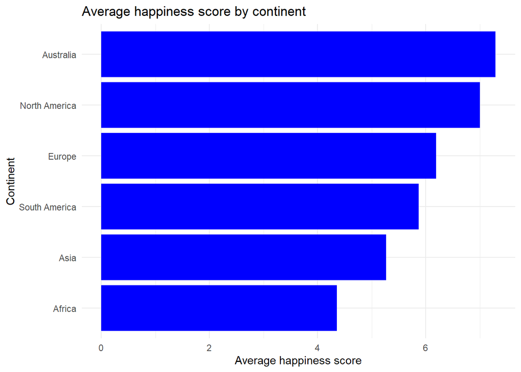

```r
ggplot(continent_summary,
       aes(x = reorder(continent, Mean_Happiness), y = Mean_Happiness)) +
  geom_col(fill = "blue") +
  coord_flip() +
  labs(title = "Average happiness score by continent",
       x = "Continent", y = "Average happiness score") +
  theme_minimal()
```

# Summary by year

```r
year_summary <-Happiness_corruption %>%
  group_by(Year) %>%
  summarise(Observations = n(),
            Mean_Happiness = mean(happiness_score, na.rm = TRUE),
            Mean_CPI = mean(cpi_score, na.rm = TRUE),
            Mean_GDP = mean(gdp_per_capita, na.rm = TRUE),
            .groups = "drop")

print(year_summary, digits = 3,
      caption = "Summary statistics by year")
```

```
## # A tibble: 6 × 5
##    Year Observations Mean_Happiness Mean_CPI Mean_GDP
##   <int>        <int>          <dbl>    <dbl>    <dbl>
## 1  2015          132           5.44     44.5    1.01
## 2  2016          132           5.44     44.3    0.864
## 3  2017          132           5.51     44.3    0.933
## 4  2018          132           5.46     44.2    0.913
## 5  2019          132           5.43     44.3    0.967
## 6  2020          132           5.56     44.4    0.891
```

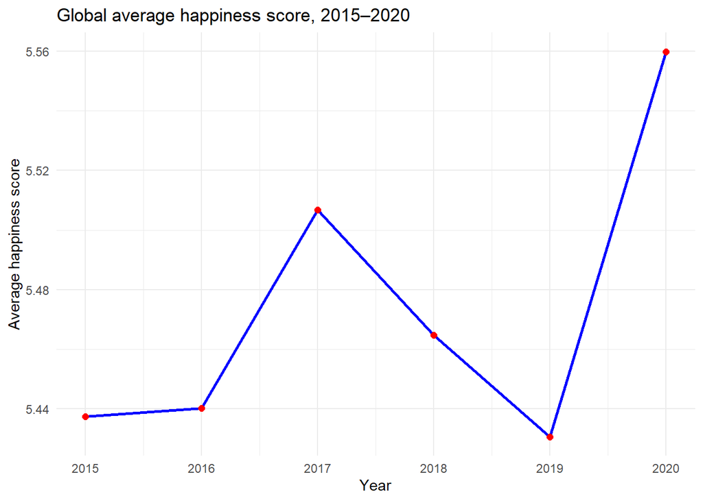

```r
ggplot(year_summary, aes(x = Year, y = Mean_Happiness)) +
  geom_line(linewidth = 1, colour = "blue") +
  geom_point(size = 2, colour = "red") +
  scale_x_continuous(breaks = sort(unique(Happiness_corruption$Year))) +
  labs(title = "Global average happiness score, 2015–2020",
       x = "Year", y = "Average happiness score") +
  theme_minimal()
```

#Happiness Score, CPI Score and GDP per Capita.

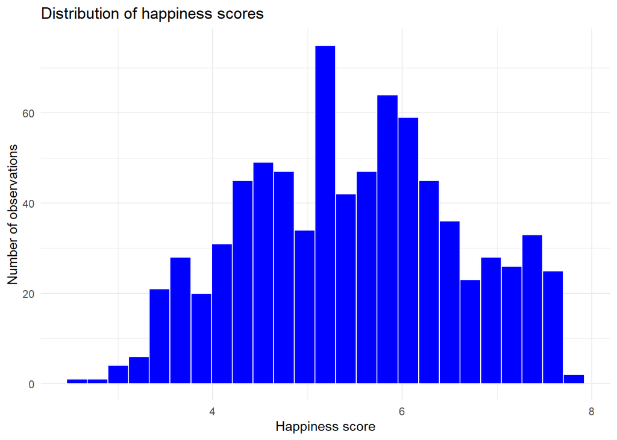

```r
p1 <- ggplot(Happiness_corruption , aes(x = happiness_score)) +
  geom_histogram(bins = 25, fill = "blue", colour = "white") +
  labs(title = "Distribution of happiness scores",
       x = "Happiness score", y = "Number of observations") +
  theme_minimal()

p2 <- ggplot(Happiness_corruption , aes(x = cpi_score)) +
  geom_histogram(binwidth = 10, boundary = 0,
                 fill = "green", colour = "white") +
  labs(title = "Distribution of CPI scores",
       x = "CPI score", y = "Number of observations") +
  theme_minimal()

p3 <- ggplot(Happiness_corruption , aes(x = gdp_per_capita)) +
  geom_histogram(bins = 25, fill = "orange", colour = "white") +
  labs(title = "Distribution of GDP per capita",
       x = "GDP per capita", y = "Number of observations") +
  theme_minimal()
p1
```

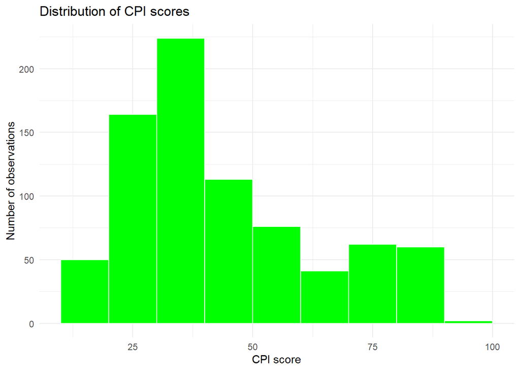

```r
p2
```

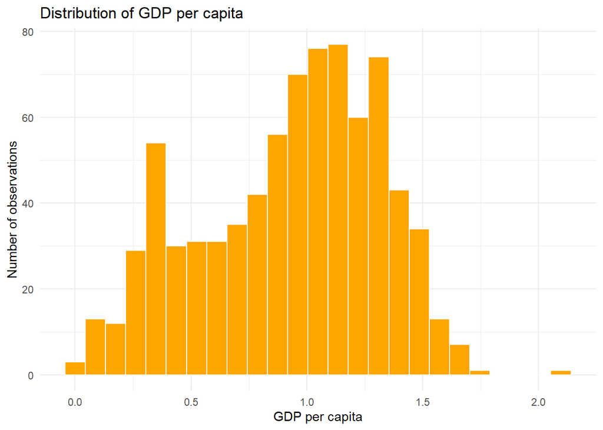

```r
p3
```

The EDA shows that . . . 28.79. . . . . % of the observations come from European coun- tries. Moreover, . . . .248 . . . . out of all country–year observations have a CPI score

of 50 or above. In addition, the average happiness score of Europe is . .1.42 . . . . . .

times the average happiness score of Africa. Generally, the global average happi- ness score moved from . . . 5.4375. . . . . in 2015 to . . . . .5.5599 . . . in 2020.

##4.3 How does the happiness score vary by continent,year,and by CPI score group #How does the happiness score vary by continent

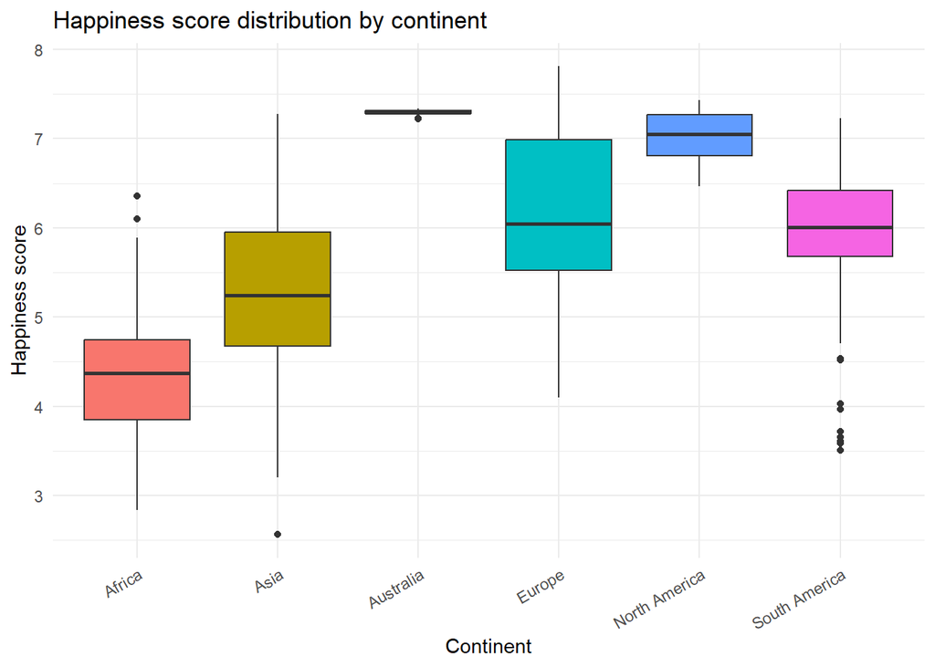

```r
ggplot(Happiness_corruption, aes(x = continent, y = happiness_score, fill = continent)) +
  geom_boxplot(show.legend = FALSE) +
  labs(title = "Happiness score distribution by continent",
       x = "Continent", y = "Happiness score") +
  theme_minimal() +
  theme(axis.text.x = element_text(angle = 30, hjust = 1))
```

#How does the happiness score vary by year

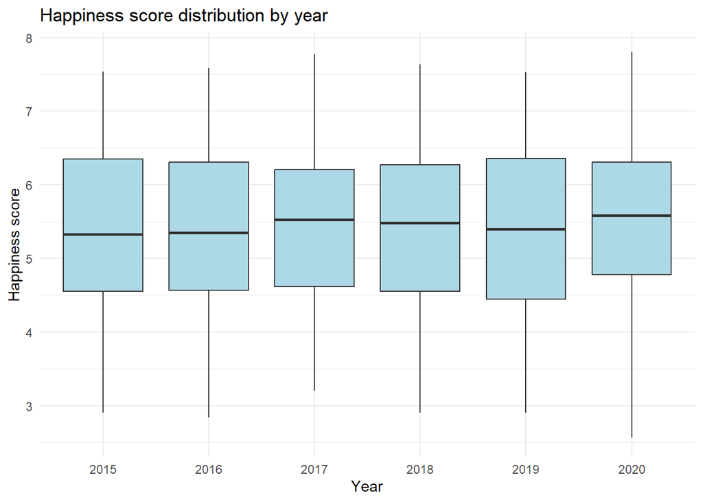

```r
ggplot(Happiness_corruption, aes(x = factor(Year), y = happiness_score,
                 group = Year)) +
  geom_boxplot(fill = "lightblue") +
  labs(title = "Happiness score distribution by year",
       x = "Year", y = "Happiness score") +
  theme_minimal()
```

#How does the happiness score vary by CPI score group

```r
 Happiness_corruption<- Happiness_corruption %>%
  mutate(CPI_Group = cut(cpi_score,
                        breaks = seq(0, 100, by = 10),
                        right = FALSE,
                        include.lowest = TRUE,
                        labels = paste(seq(0, 90, 10),
                                       seq(9, 99, 10), sep = "–")))

cpi_group_summary <- Happiness_corruption %>%
  group_by(CPI_Group) %>%
  summarise(Observations = n(),
            Mean_Happiness = mean(happiness_score, na.rm = TRUE),
            .groups = "drop")

print(cpi_group_summary, digits = 3,
      caption = "Average happiness by CPI interval")
```

```
## # A tibble: 9 × 3
##   CPI_Group Observations Mean_Happiness
##   <fct>            <int>          <dbl>
## 1 10–19               40           4.48
## 2 20–29              151           4.85
## 3 30–39              229           5.13
## 4 40–49              124           5.21
## 5 50–59               70           5.73
## 6 60–69               45           5.95
## 7 70–79               65           6.76
## 8 80–89               63           7.24
## 9 90–99                5           7.42
```

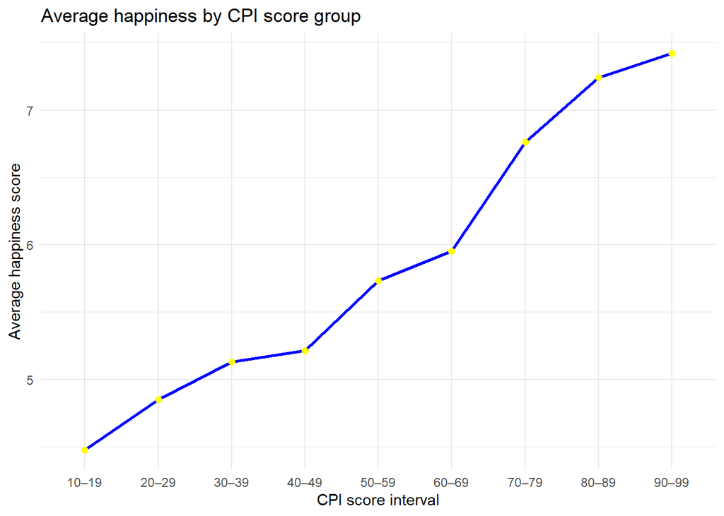

```r
ggplot(cpi_group_summary,
       aes(x = CPI_Group, y = Mean_Happiness, group = 1)) +
  geom_line(colour = "blue", linewidth = 1) +
  geom_point(size = 2, colour = "yellow") +
  labs(title = "Average happiness by CPI score group",
       x = "CPI score interval", y = "Average happiness score") +
  theme_minimal()
```

## Scatter plot and correlation between CPI and happiness

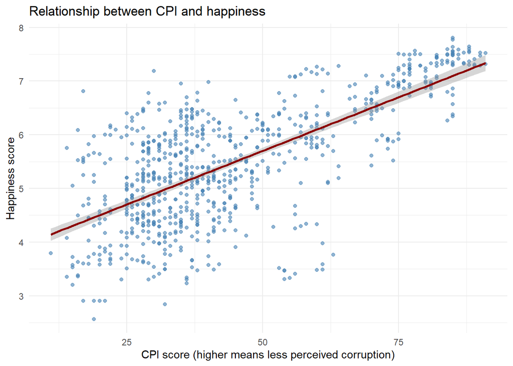

```r
ggplot(Happiness_corruption, aes(x = cpi_score, y = happiness_score)) +
  geom_point(alpha = 0.6, colour = "steelblue") +
  geom_smooth(method = "lm", se = TRUE, colour = "darkred") +
  labs(title = "Relationship between CPI and happiness",
       x = "CPI score (higher means less perceived corruption)",
       y = "Happiness score") +
  theme_minimal()
```

```r
cpi_happiness_correlation <- cor(Happiness_corruption$cpi_score,
                                 Happiness_corruption$happiness_score,
                                 use = "complete.obs",
                                 method = "pearson")
cpi_happiness_correlation
```

```
## [1] 0.6930014
```

#4.4Identify one group of countries with a notably low happiness level.

```r
low_group <-Happiness_corruption %>%
  filter(continent == "Africa", cpi_score < 30)

low_group_countries <- sort(unique(low_group$Country))
low_group_mean <- mean(low_group$happiness_score, na.rm = TRUE)
global_mean <- mean(Happiness_corruption$happiness_score, na.rm = TRUE)
difference <- low_group_mean - global_mean
percent_below <- 100 * (global_mean - low_group_mean) / global_mean

print(low_group %>%
        group_by(Country) %>%
        summarise(Observations = n(),
                  Average_Happiness = mean(happiness_score),
                  Average_CPI = mean(cpi_score),
                  .groups = "drop") %>%
        arrange(Average_Happiness),
      digits = 3,
      caption = "Countries in the selected low-happiness group")
```

```
## # A tibble: 14 × 4
##    Country      Observations Average_Happiness Average_CPI
##    <chr>               <int>             <dbl>       <dbl>
##  1 Burundi                 6              3.20        19.7
##  2 Togo                    2              3.75        29
##  3 Madagascar              6              3.82        25.3
##  4 Zimbabwe                6              3.89        22.5
##  5 Mali                    1              4.07        29
##  6 Chad                    6              4.07        20.3
##  7 Uganda                  6              4.09        26.2
##  8 Liberia                 2              4.09        28
##  9 Mauritania              5              4.37        27.8
## 10 Kenya                   5              4.45        26.8
## 11 Sierra Leone            1              4.71        29
## 12 Cameroon                6              4.76        25.5
## 13 Nigeria                 6              5.06        26.5
## 14 Libya                   6              5.58        16.5
```

```r
cat("Number of country-year observations:", nrow(low_group), "\n")
```

```
## Number of country-year observations: 64
```

```r
cat("Number of distinct countries:", length(low_group_countries), "\n")
```

```
## Number of distinct countries: 14
```

```r
cat("Countries:", paste(low_group_countries, collapse = ", "), "\n")
```

```
## Countries: Burundi, Cameroon, Chad, Kenya, Liberia, Libya, Madagascar, Mali, Mauritania, Nigeria, Sierra Leone, Togo, Uganda, Zimbabwe
```

```r
cat("Group average happiness:", round(low_group_mean, 3), "\n")
```

```
## Group average happiness: 4.302
```

```r
cat("Global average happiness:", round(global_mean, 3), "\n")
```

```
## Global average happiness: 5.473
```

```r
cat("Difference (group minus global):", round(difference, 3), "\n")
```

```
## Difference (group minus global): -1.171
```

```r
cat("Group average is", round(percent_below, 1),
    "% below the global average.\n")
```

```
## Group average is 21.4 % below the global average.
```

#4.5 Provide five practical recommendations for policymakers who want to improve #citizenswell-being, based on your analysis. ́

1.Prioritise countries and communities facing observations with CPI below 30 because they have a lower average happiness score than the global average.

2.Policymakers should protect civil rights, improve access to information and create meaningful opportunities for citizens to participate in decisions that affect them(personal freedom)

3.Promote transparent and accountable institutions 4.Improve public health and access to healthcare 5.Strengthen economic opportunity